# Simulations to support concepts in main text - Myth 5: DAGs are not useful in randomized experiments

allisonsimlerwil@boisestate.edu

Modified: October 2026

**Purpose:** This script provides data simulations to reinforce concepts described in Myth 5: DAGs are not useful in randomized experiments.

Adapted from teaching materials by A. Simler-Williamson.

```r
library(tidyverse)
library(broom)
library(patchwork)
```

# Simulation 1a: Small sample sizes, chance imbalance in drivers of the outcome, and randomization “failure” in controlled experiments

Randomization removes confounding in expectation in controlled experiments, however, especially at small sample sizes, chance imbalance in covariates can emerge, generating statistical bias.

The loop below simulates an experiment (100 times) with the following scenario: We are studying the effects of bison on soil carbon, using a fencing exclosure treatment to manipulate bison occurrence. Fence treatments are deployed randomly. Precipitation also influences soil carbon. In expectation, randomization of the treatment should remove any possible confounding from precipitation (precipitation does not impact the treatment, so that arrow can be removed from our DAG); however, at small sample sizes, we can still see chance imbalance in precipitation that causes bias in our estimated treatment effect.

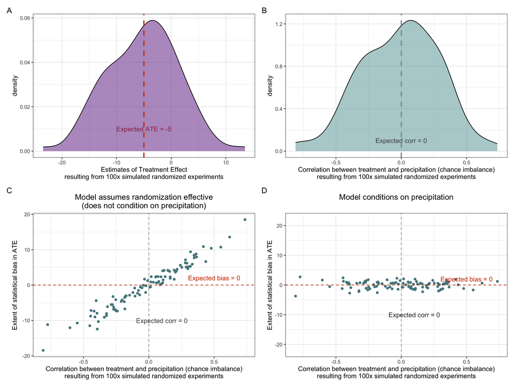

```r
# Make some vectors to store our simulation results
ate_random_naive <- c() # ATE = average treatment effect from each simulated experiment
ate_random_DAG  <- c() # ATE when controlling for accidental imbalance emerging at small samples
imbalance <- c() # We will also store info about chance imbalance in precip between treatments.


set.seed(1234)
for (i in 1:100) {  ## For i in 100 simulations of the experiment above
  N <- 12 # Set sample size to 10 observations (plots)

  # Sample size is divided among our 2 treatment levels (1=fenced; 0=unfenced)
  fenced <- rep(c(0,1), N/2)

  # precipitation varies from 1cm to 5cm in our study area.
  # (runinf() generates random draws from the uniform distribution).
  precip <- runif(N, min=1, max=5)

  # Now, generate the outcome, based on our generative model:
  ## Fencing exclosures influence soil carbon with a "true" effect of -5 (removing bison reduces carbon)
  ## Precipitation increases soil carbon with a "true" effect of 10
  ## HOWEVER, there is no relationship between bison and precip at this time IN EXPECTATION

  ## This is the deterministic portion of our generative model: B0 + B1*X1 + B2*X2
  mu <- 10 + 10*precip - 5*fenced
  ## this is the sd for our normal distribution
  sigma <- 2
  ## This simulates carbon (the outcome) using the normal probability distribution
  carbon <- rnorm(N, mu, sigma)
  random.design <- data.frame(precip, fenced, carbon) ## Make it into a dataframe

  # Fit model that ignores precipitation. Just condition on the bison fencing treatment:
  naivemodel <- lm(carbon~fenced, data=random.design)
  DAGmodel <- lm(carbon~fenced + precip, data=random.design)

  # Extract estimates for treatment effect & p-vals
  ate_random_naive[i] <- coef(naivemodel)["fenced"]
  ate_random_DAG[i] <- coef(DAGmodel)["fenced"]
  imbalance[i] <- cor(random.design$precip, random.design$fenced)
}
```

# Simulation 1b: How does the risk of chance imbalance change with sample size?

Repeat the same experiment (same generative model as above) 100x at each of several sample sizes.

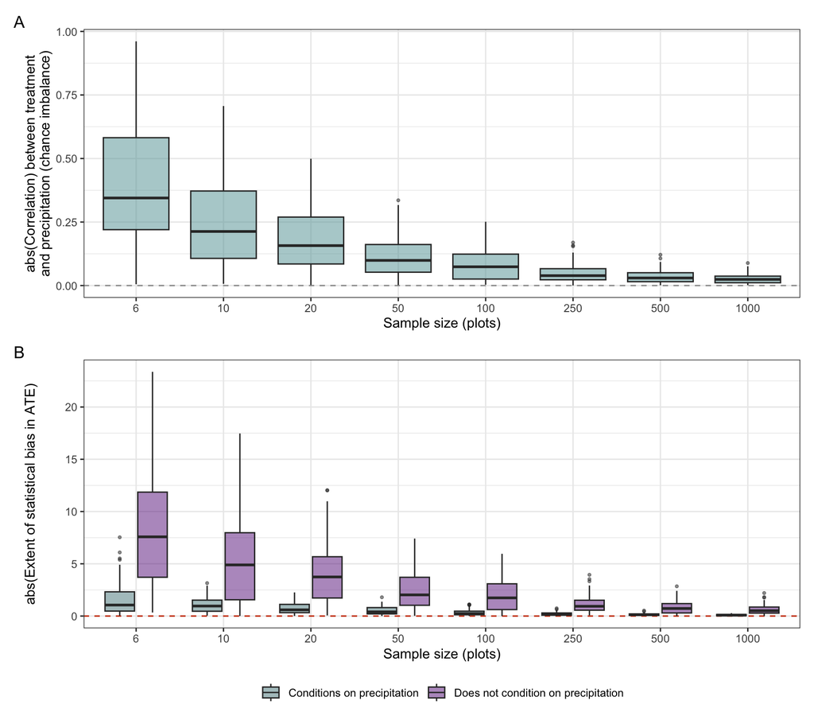

```r
sample_sizes <- c(6, 10, 20, 50, 100, 250, 500, 1000)

sim_by_N <- map_dfr(sample_sizes, function(N) {
  map_dfr(1:100, function(i) {
    fenced <- rep(c(0,1), N/2)
    precip <- runif(N, min=1, max=5)
    carbon <- rnorm(N, 10 + 10*precip - 5*fenced, 2)
    tibble(N = N,
           imbalance = cor(precip, fenced),
           naive = coef(lm(carbon ~ fenced))["fenced"],
           DAG   = coef(lm(carbon ~ fenced + precip))["fenced"])
  })
})
```

**Figure 2.** Results of simulated experiments (100 iterations) at varying sample sizes, from n=6 to n=1000. Panel A demonstrates how the risk of chance imbalance in precipitation between treatment groups (expressed as the absolute value of the correlation between precipitation and treatment ID) decreases as sample size increases. Panel B demonstrates that, as chance imbalance decreases with increasing sample size, so does the threat of statistical bias (expressed as the absolute value of the difference between the estimated ATE and the “true” treatment effect). Conditioning on precipitation addresses the statistical bias associated with chance imbalance in precipitation, and remaining deviations from the “true” treatment effect are caused by random sampling error.